# New York Schools and County Socioeconomic Conditions

Yifei Bu

# Introduction

The analysis uses school-level data from the New York State Department of Education and county-level data from the American Community Survey.

Missing values originally coded as -99 were converted to NA. Invalid percentage values were also treated as missing. Because New York State test scales changed over time, Math and ELA scores were standardized within each year using z-scores.

# Poverty Groups

Counties were divided into three approximately equal-sized groups within each year based on their poverty rate. Counties in the lowest third were classified as low poverty, those in the middle third as medium poverty, and those in the highest third as high poverty.

```r
county_year_summary <- read_csv(
  "data/processed/county_year_summary.csv",
  show_col_types = FALSE
)

poverty_extremes <- read_csv(
  "data/processed/poverty_extremes.csv",
  show_col_types = FALSE
)

poverty_group_summary <- read_csv(
  "data/processed/poverty_group_summary.csv",
  show_col_types = FALSE
)
```

# Summary Tables

## Counties with the Highest and Lowest Poverty Rates

```r
knitr::kable(
  poverty_extremes,
  digits = 2,
  caption = "Counties with the Highest and Lowest Average Poverty Rates"
)
```

Counties with the Highest and Lowest Average Poverty Rates

| county_name | avg_poverty | avg_free_reduced | avg_ela_z | avg_math_z | poverty_level |
| --- | --- | --- | --- | --- | --- |
| NASSAU | 0.06 | 0.23 | 0.80 | 0.73 | Lowest 5 |
| PUTNAM | 0.06 | 0.14 | 0.57 | 0.53 | Lowest 5 |
| SUFFOLK | 0.06 | 0.30 | 0.30 | 0.25 | Lowest 5 |
| SARATOGA | 0.06 | 0.20 | 0.65 | 0.53 | Lowest 5 |
| DUTCHESS | 0.08 | 0.32 | 0.08 | -0.09 | Lowest 5 |
| BRONX | 0.29 | 0.86 | -0.73 | -0.64 | Highest 5 |
| KINGS | 0.22 | 0.77 | -0.05 | 0.02 | Highest 5 |
| MONTGOMERY | 0.18 | 0.54 | -0.57 | -0.50 | Highest 5 |
| CHAUTAUQUA | 0.18 | 0.54 | -0.25 | -0.19 | Highest 5 |
| TOMPKINS | 0.18 | 0.39 | 0.16 | 0.07 | Highest 5 |

# Lunch Assistance and Academic Performance

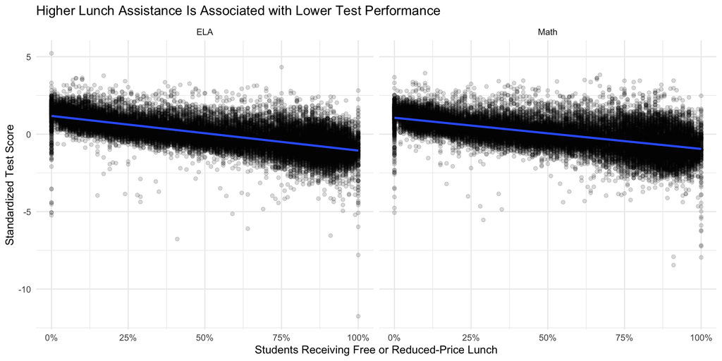

# Key Findings

These results describe associations in the data and should not be interpreted as evidence that poverty or lunch-program participation directly causes differences in test scores.